# Лабораторная работа №8

Имитационное моделирование

Самарханова Полина Тимуровна

1132236021@rudn.ru

Российский университет дружбы народов

## Задания

- Создать рабочий каталог для всего курса. -Установить необходимые пакеты.
- Выполнить предложенный код.
- Преобразовать код в литературный стиль.
- Сгенерировать из литературного кода:
  - чистый код;
  - jupyter notebook;
  - документацию в формате Quarto.
- Выполнить код из jupyter notebook.
- Интегрировать документацию в формате Quarto в отчёт.
- Добавить в код в литературном стиле вычисление для набора параметров.
- Сгенерировать из литературного кода с параметрами:
  - чистый код;
  - jupyter notebook;
  - документацию в формате Quarto.
- Выполнить код из jupyter notebook с параметрами.
- Интегрировать документацию с параметрами в формате Quarto в отчёт.

## Цели и задачи

# Выполнение

## Структура программы(sir_model.jl)

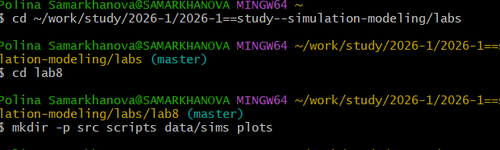

Перехожу в каталог лабораторной работ и создаю папки src, plots, data, scripts и перехожу в папку лабораторной работы 8

Создала файл sir_model.jl

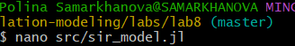

файл

В открывшемся окне вставила код из методички(это только модуль с моделью, запуск не нужен)

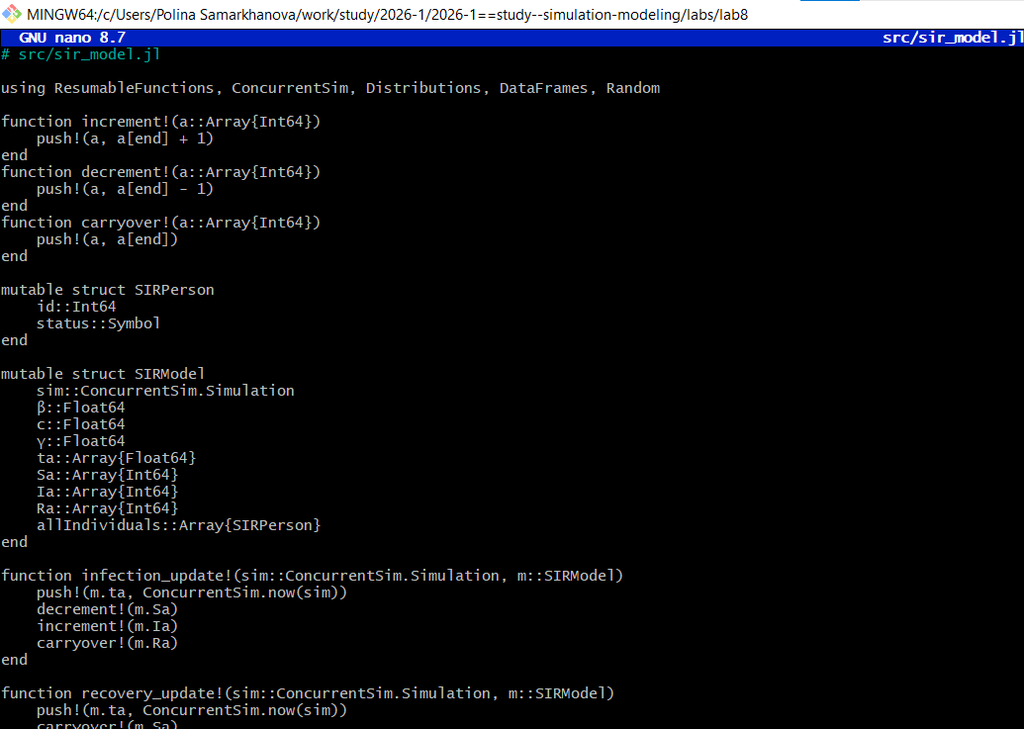

код

## Скрипт запуска(sir_des.jl)

Создала файл для прогона модели

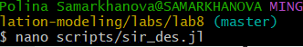

файл

В открывшемся окне вставила код для модели

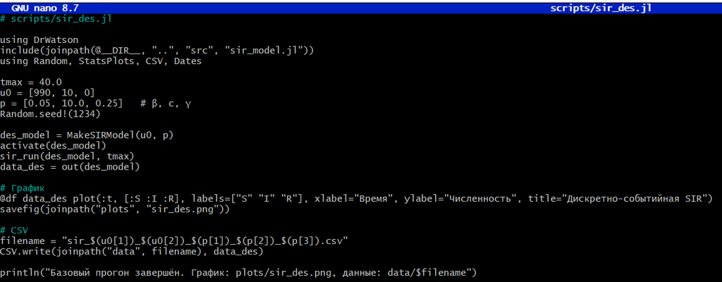

код

Запустила код и получила результаты

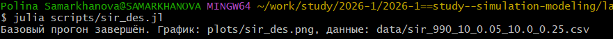

запуск

График Дискретно-событийная SIR

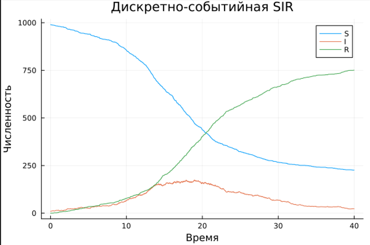

график

## Анализ чувствительности к параметрам

Создала файл

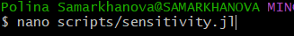

файл

В открывшемся окне вставила код

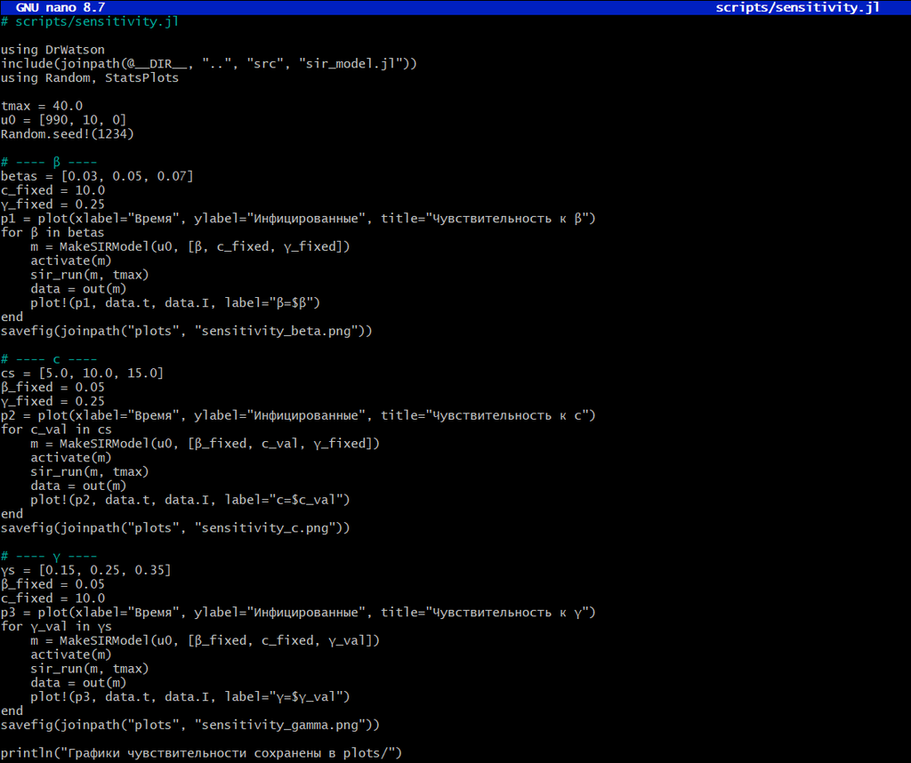

код

Запустила код и получила результаты

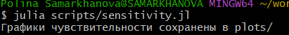

запуск

График чувствительности к b

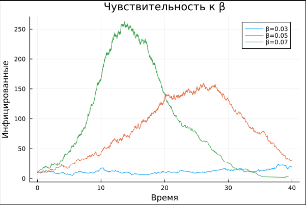

график 1

График чувствительности к c

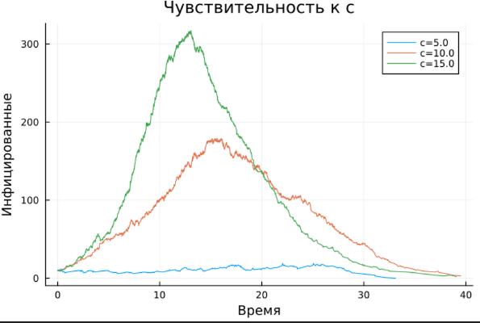

график 2

График чувствительности к y

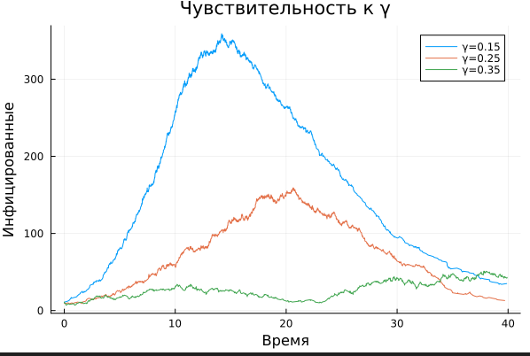

график 3

## Детерминированная длительность болезни

Создала файл

В открывшемся окне вставила код

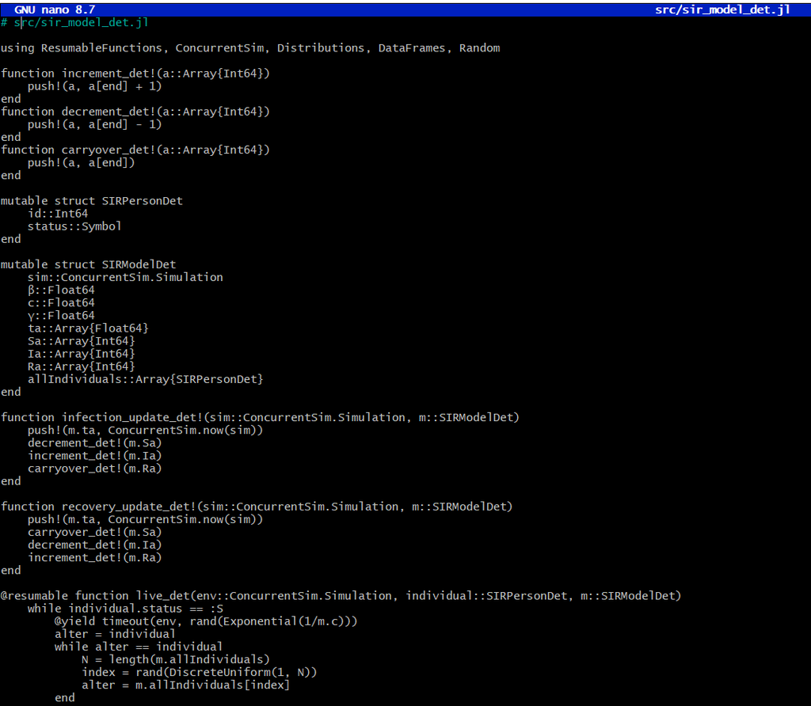

код

Создала файл для запуска скрипта и написала код

Запустила код и получила результаты

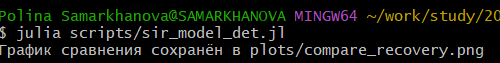

запуск

График значения случайного и фикированного времени выздоровления

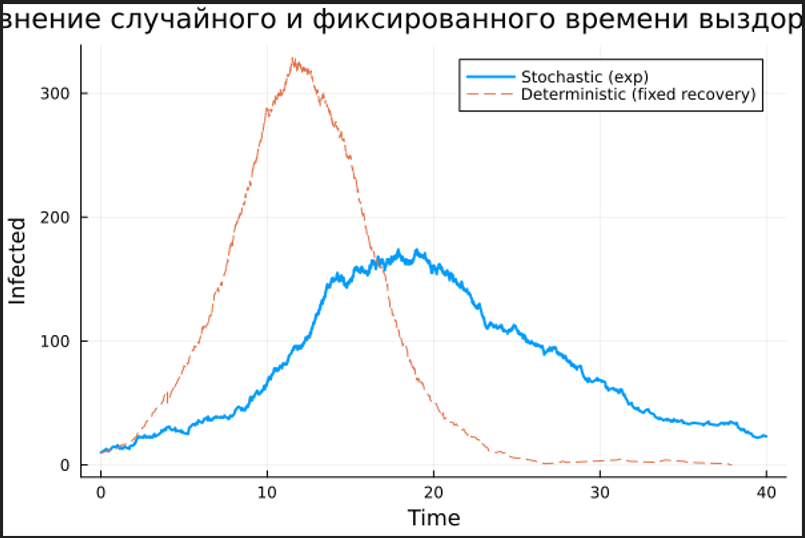

график

## Оценка производительности

Создала файл

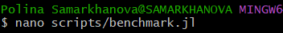

файл

В открывшемся окне вставила код

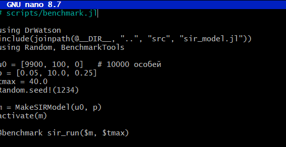

код

Запустила код и получила результаты

[figure not shown]

результаты

## Вакцинация

Создала файл

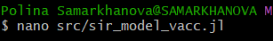

файл

В открывшемся окне вставила код

[figure not shown]

код

Создала файл для запуска скрипта

Вставила код

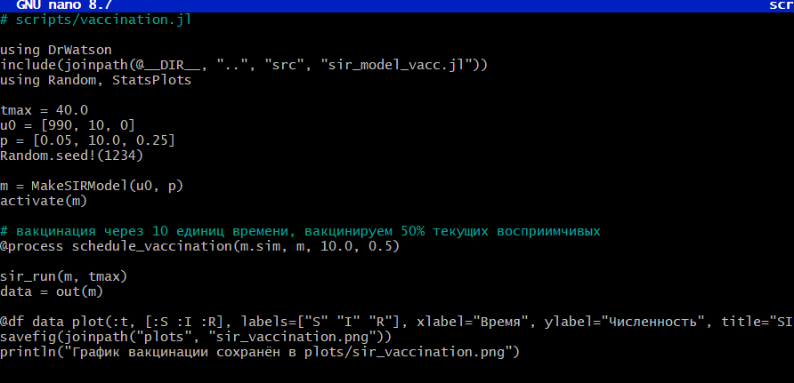

код

Запустила код и получила результаты

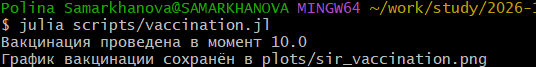

запуск

График SIR с вакцинацией 50% S на 10-й день

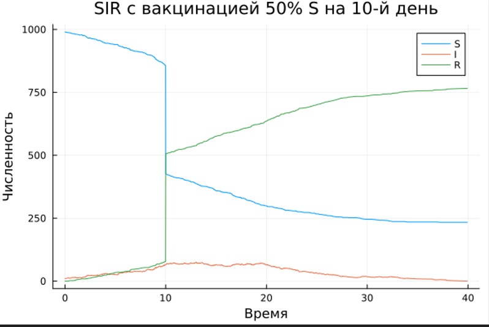

график

## Модель SEIR

Создала файл

В открывшемся окне вставила код

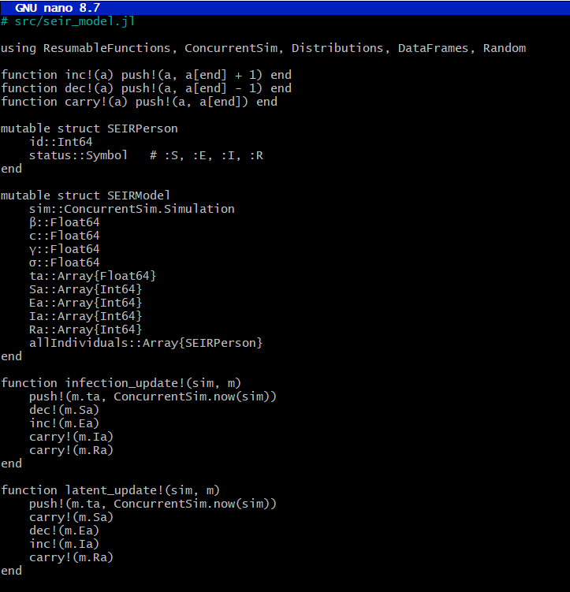

код

Создала файл для запуска скрипта

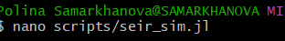

файл

Вставила код

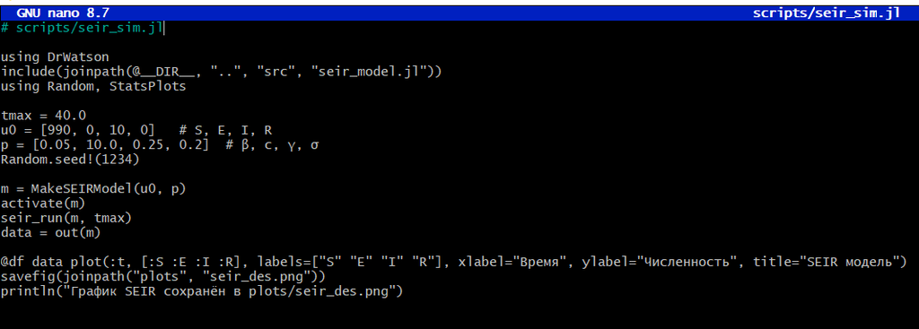

код

Запустила код и получила результаты

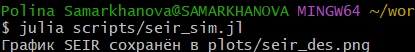

запуск

График SEIR

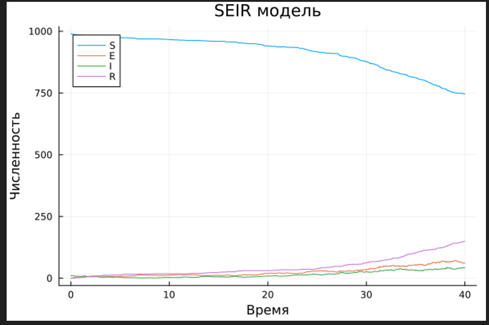

график

Спасибо за внимание !